# FeLV snakemake workflow notes

Cait McDonald

Last Updated: 2021-05-05

#### Note: this largely follows Eric Anderson’s [microhap workflow](https://github.com/eriqande/mega-simple-microhap-snakeflow).

I’m also trying to write these notes so they can work as a Snakemake tutorial as well, for when I inevitably forget what I’ve done.

## Organizing my data

Input data is all stored within a `data/` directory, which includes:

```r
library(here)
library(tidyverse)
library(knitr)

metadata <- read_delim("data/felv_metadata.tsv", delim="\t")
head(metadata)
```

| cat_id | id_inf | cell_type | population | status | index | sample_id | no_ext | fastq1 | fastq2 |
| --- | --- | --- | --- | --- | --- | --- | --- | --- | --- |
| 4438 | 4438 | PBMC | SPF | uninfected | S1 | S01 | 4438_S1_L002 | 4438_S1_L002_R1_001.fastq.gz | 4438_S1_L002_R2_001.fastq.gz |
| 4460 | 4460 | PBMC | SPF | uninfected | S2 | S02 | 4460_S2_L002 | 4460_S2_L002_R1_001.fastq.gz | 4460_S2_L002_R2_001.fastq.gz |
| 4474 | 4474 | PBMC | SPF | uninfected | S3 | S03 | 4474_S3_L002 | 4474_S3_L002_R1_001.fastq.gz | 4474_S3_L002_R2_001.fastq.gz |
| 4501 | 4501 | PBMC | SPF | uninfected | S4 | S04 | 4501_S4_L002 | 4501_S4_L002_R1_001.fastq.gz | 4501_S4_L002_R2_001.fastq.gz |
| 4510 | 4510 | PBMC | SPF | uninfected | S5 | S05 | 4510_S5_L002 | 4510_S5_L002_R1_001.fastq.gz | 4510_S5_L002_R2_001.fastq.gz |
| 4520 | 4520 | PBMC | SPF | uninfected | S6 | S06 | 4520_S6_L002 | 4520_S6_L002_R1_001.fastq.gz | 4520_S6_L002_R2_001.fastq.gz |

We can set this as our run dir in our `config.yaml` file.

## Notes on organization

For [reproducibility](https://snakemake.readthedocs.io/en/stable/snakefiles/deployment.html), it’s best to organize your directories as suggested:

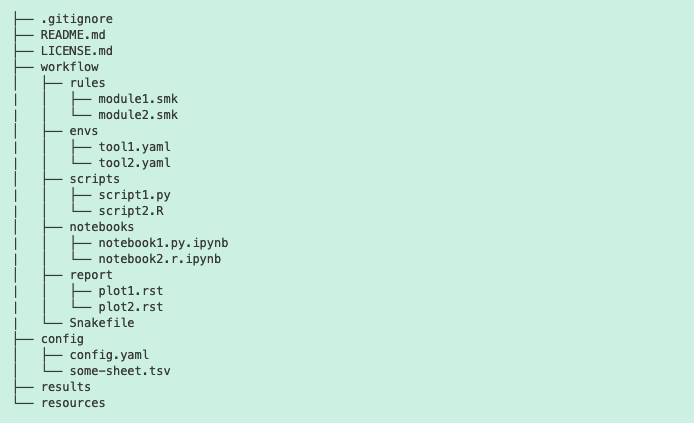

So, all rules are written as individual `.smk` files in a `rules` directory, and then called by the Snakefile. Note that when thinking about paths, you do *not* need to include `workflow/` because Snakemake infers it (so `envs/tool1.yaml`, not `workflow/envs/tool1.yaml`).

## Designing the workflow

To avoid rewriting rules for future projects, I want to write rules that are as modular as possible. My workflow for this project is:

1. QC
2. Read trimming
3. QC
4. STAR (align and quant)

So, my goal will be to write just one QC rule such that I can call it for raw and trimmed reads. I also want to make sure the read trimming rule could work equally well for RNAseq or ddRAD data. From here, I could easily add in rules for other programs (e.g. Trinity, bowtie2, RSEM, salmon).

## Writing and testing rules

To make the QC rule modular for both raw and trimmed reads, I need to figure out some sort of wildcard for file paths and naming, in addition to the standard wildcard for sample.

Hmmm and we can add even more modularity by putting function definitions that might be called by multiple rules into a `common.smk` file…for example, within that common file I could have:

```bash
def get_raw_fastqs(wildcards):
    """Get path to raw fastq files"""
    return r"{run_dir}/raw/{fq}".format(run_dir=wildcards.run_dir, fq=wildcards.fq)

def get_trimmed_fastqs(wildcards):
    """Get path to trimmed fastq files"""
    return r"{run_dir}/trimmed/{fq}".format(run_dir=wildcards.run_dir, fq=wildcards.fq)
```